# Lesson 4

### Урок 4. Предварительный анализ данных и визуализация с помощью Matplotlib и Seaborn

1. Скачать датасет о качестве КРАСНОГО вина по ссылке. https://archive.ics.uci.edu/ml/datasets/wine+quality
2. На основе переменной quality с оценками вина создать новую переменную good: если quality > 5, то 1, иначе 0.
3. Исследовать, какие химические характеристики вина влияют на то, окажется оно хорошим или плохим, с применением не менее 5 диаграмм из урока.
4. Отчет сделать в формате storytelling: дополнить каждый график письменными выводами и наблюдениями.

#### Задание 1

```python
# Импортируем нужные библиотеки
import pandas as pd
import numpy as np
import matplotlib.pyplot as plt #работает с графиками и диаграммами
import seaborn as sns #работает с графиками и диаграммами

# Считываем датасет
df = pd.read_csv('winequality-red.csv', sep = ';')
df.sample(n = 10)
```

|  | fixed acidity | volatile acidity | citric acid | residual sugar | chlorides | free sulfur dioxide | total sulfur dioxide | density | pH | sulphates | alcohol | quality |
| --- | --- | --- | --- | --- | --- | --- | --- | --- | --- | --- | --- | --- |
| 199 | 6.9 | 1.090 | 0.06 | 2.1 | 0.061 | 12.0 | 31.0 | 0.99480 | 3.51 | 0.43 | 11.4 | 4 |
| 953 | 10.2 | 0.340 | 0.48 | 2.1 | 0.052 | 5.0 | 9.0 | 0.99458 | 3.20 | 0.69 | 12.1 | 7 |
| 918 | 8.4 | 0.360 | 0.32 | 2.2 | 0.081 | 32.0 | 79.0 | 0.99640 | 3.30 | 0.72 | 11.0 | 6 |
| 727 | 6.4 | 0.570 | 0.02 | 1.8 | 0.067 | 4.0 | 11.0 | 0.99700 | 3.46 | 0.68 | 9.5 | 5 |
| 472 | 12.5 | 0.370 | 0.55 | 2.6 | 0.083 | 25.0 | 68.0 | 0.99950 | 3.15 | 0.82 | 10.4 | 6 |
| 239 | 8.2 | 1.000 | 0.09 | 2.3 | 0.065 | 7.0 | 37.0 | 0.99685 | 3.32 | 0.55 | 9.0 | 6 |
| 555 | 15.5 | 0.645 | 0.49 | 4.2 | 0.095 | 10.0 | 23.0 | 1.00315 | 2.92 | 0.74 | 11.1 | 5 |
| 952 | 8.2 | 0.310 | 0.40 | 2.2 | 0.058 | 6.0 | 10.0 | 0.99536 | 3.31 | 0.68 | 11.2 | 7 |
| 804 | 8.4 | 0.520 | 0.22 | 2.7 | 0.084 | 4.0 | 18.0 | 0.99682 | 3.26 | 0.57 | 9.9 | 6 |
| 849 | 6.4 | 0.630 | 0.21 | 1.6 | 0.080 | 12.0 | 32.0 | 0.99689 | 3.58 | 0.66 | 9.8 | 5 |

#### Задание 2

На основе переменной quality с оценками вина создать новую переменную good: если quality > 5, то 1, иначе 0.

```python
df['good'] = df['quality'].apply(lambda x: 1 if x>5 else 0)
df.sample(n = 10)
```

|  | fixed acidity | volatile acidity | citric acid | residual sugar | chlorides | free sulfur dioxide | total sulfur dioxide | density | pH | sulphates | alcohol | quality | good |
| --- | --- | --- | --- | --- | --- | --- | --- | --- | --- | --- | --- | --- | --- |
| 174 | 7.3 | 0.38 | 0.21 | 2.0 | 0.080 | 7.0 | 35.0 | 0.99610 | 3.33 | 0.47 | 9.5 | 5 | 0 |
| 801 | 8.6 | 0.55 | 0.09 | 3.3 | 0.068 | 8.0 | 17.0 | 0.99735 | 3.23 | 0.44 | 10.0 | 5 | 0 |
| 392 | 9.5 | 0.37 | 0.52 | 2.0 | 0.082 | 6.0 | 26.0 | 0.99800 | 3.18 | 0.51 | 9.5 | 5 | 0 |
| 55 | 7.7 | 0.62 | 0.04 | 3.8 | 0.084 | 25.0 | 45.0 | 0.99780 | 3.34 | 0.53 | 9.5 | 5 | 0 |
| 1237 | 7.1 | 0.75 | 0.01 | 2.2 | 0.059 | 11.0 | 18.0 | 0.99242 | 3.39 | 0.40 | 12.8 | 6 | 1 |
| 593 | 9.9 | 0.49 | 0.58 | 3.5 | 0.094 | 9.0 | 43.0 | 1.00040 | 3.29 | 0.58 | 9.0 | 5 | 0 |
| 283 | 8.9 | 0.40 | 0.32 | 5.6 | 0.087 | 10.0 | 47.0 | 0.99910 | 3.38 | 0.77 | 10.5 | 7 | 1 |
| 734 | 7.7 | 0.56 | 0.20 | 2.0 | 0.075 | 9.0 | 39.0 | 0.99870 | 3.48 | 0.62 | 9.3 | 5 | 0 |
| 1387 | 7.4 | 0.64 | 0.07 | 1.8 | 0.100 | 8.0 | 23.0 | 0.99610 | 3.30 | 0.58 | 9.6 | 5 | 0 |
| 467 | 8.8 | 0.46 | 0.45 | 2.6 | 0.065 | 7.0 | 18.0 | 0.99470 | 3.32 | 0.79 | 14.0 | 6 | 1 |

#### Задания 3, 4

Исследовать, какие химические характеристики вина влияют на то, окажется оно хорошим или плохим, с применением не менее 5 диаграмм из урока.

Для начала рассмотрим корреляционную матрицу

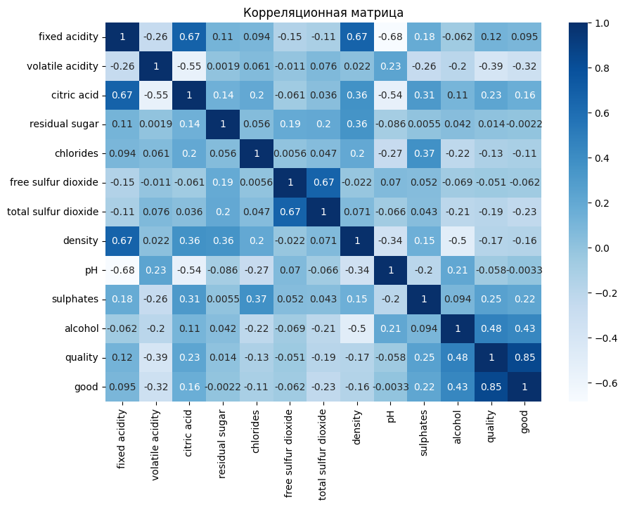

```python
correlation = df.corr()
plt.figure(figsize = (10,7))
sns.heatmap(correlation, cmap = 'Blues', annot = True)
plt.title('Корреляционная матрица')
plt.show()
```

Видим очевидную положительную корреляцию с качеством (на базе этой характеристики мы строили наш классификатор). Отметим умеренную положительную корреляцию с крепостью вина и умеренную отрицательную с содержанием летучих кислот.

Проанализируем попарные корреляции:

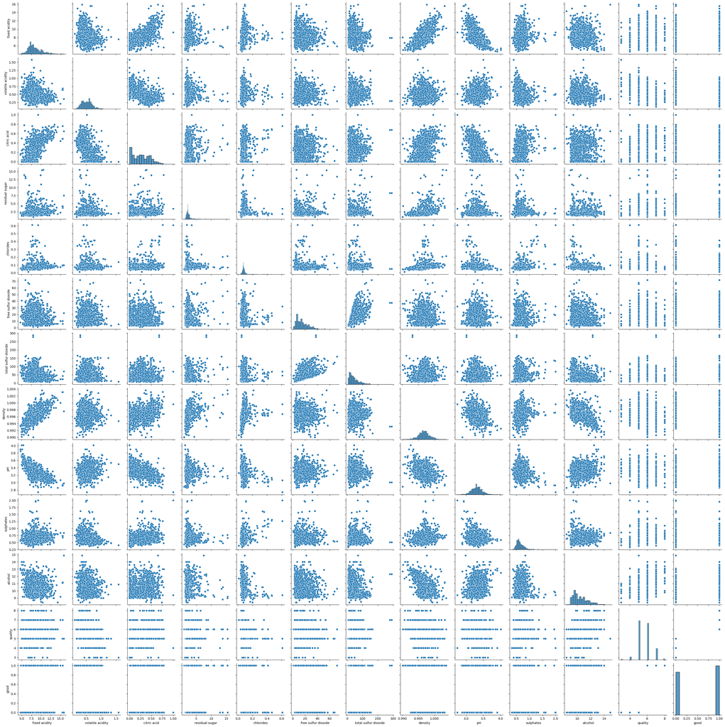

```python
sns.pairplot(df)
```

Корреляционные графики с дискретными величинами плохо проясняют ситуацию. Однако последний график свидетельствует о наличии ряда нелинейных зависимостей. Попробуем использовать для анализа выявленных корреляций другие виды диаграмм.

#### Влияние крепости вина

Рассмотрим обнаруженную корреляцию с крепостью вина более подробно

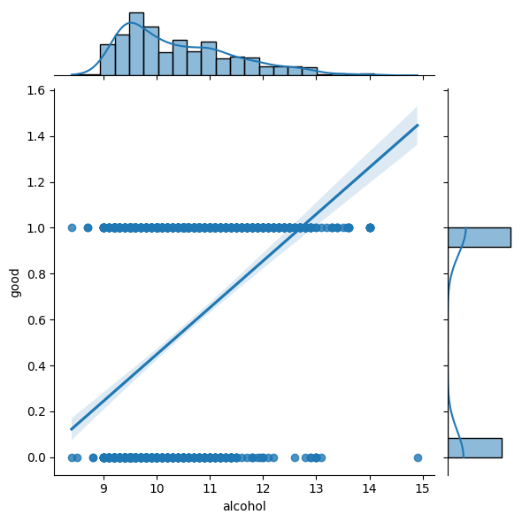

```python
sns.jointplot(x=df['alcohol'], y=df['good'], data=df, kind='reg')
```

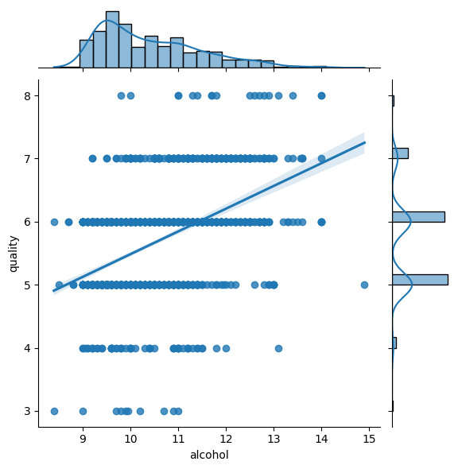

```python
sns.jointplot(x=df['alcohol'], y=df['quality'], data=df, kind='reg')
```

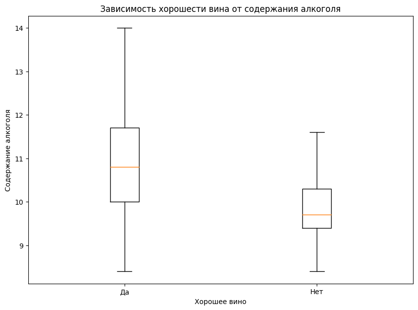

```python
data1 = df['alcohol'].loc[df['good']==1]
data2 = df['alcohol'].loc[df['good']==0]

plt.figure(figsize = (10,7))

plt.boxplot([data1, data2], showfliers = False)

plt.title('Зависимость хорошести вина от содержания алкоголя')
plt.xlabel('Хорошее вино')
plt.ylabel('Содержание алкоголя')
plt.xticks([1, 2],['Да', 'Нет'])

plt.show()
```

По приведенному выше графику видно, что менее крепкое вино в среднем окажется хуже более крепкого

#### Влияние содержания летучих кислот

```python
data3 = df.query('good == 1').groupby('quality')['volatile acidity'].mean().reset_index().sort_values(by = 'quality')
data4 = df.query('good == 0').groupby('quality')['volatile acidity'].mean().reset_index().sort_values(by = 'quality')
```

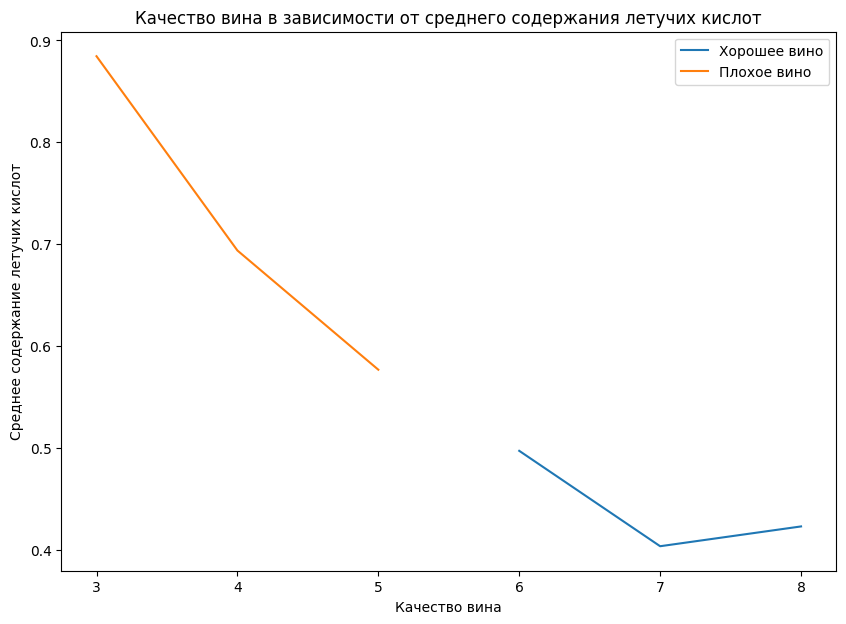

```python
plt.figure(figsize = (10,7))

plt.plot(data3['quality'], data3['volatile acidity'])
plt.plot(data4['quality'], data4['volatile acidity'])

plt.title('Качество вина в зависимости от среднего содержания летучих кислот')
plt.xlabel('Качество вина')
plt.ylabel('Среднее содержание летучих кислот')
plt.legend(['Хорошее вино','Плохое вино'])

plt.show()
```

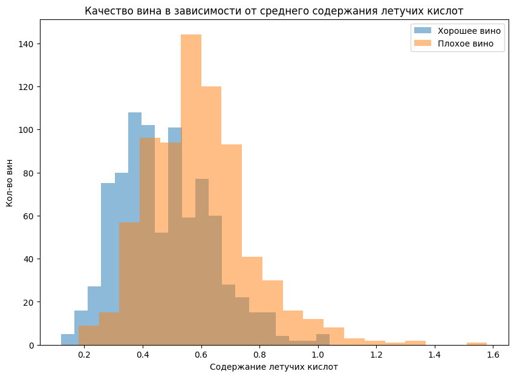

```python
plt.figure(figsize = (10,7))

plt.hist(df['volatile acidity'].loc[df['good'] == 1], bins = 20, alpha = 0.5, label = 'Хорошее вино')
plt.hist(df['volatile acidity'].loc[df['good'] == 0], bins = 20, alpha = 0.5, label = 'Плохое вино')
plt.title('Качество вина в зависимости от среднего содержания летучих кислот')
plt.xlabel('Содержание летучих кислот')
plt.ylabel('Кол-во вин')
plt.legend(['Хорошее вино','Плохое вино'])

plt.show()
```

В хорошем вине содержание летучих кислот в среднем ниже, чем в плохом

#### Прочие зависимости

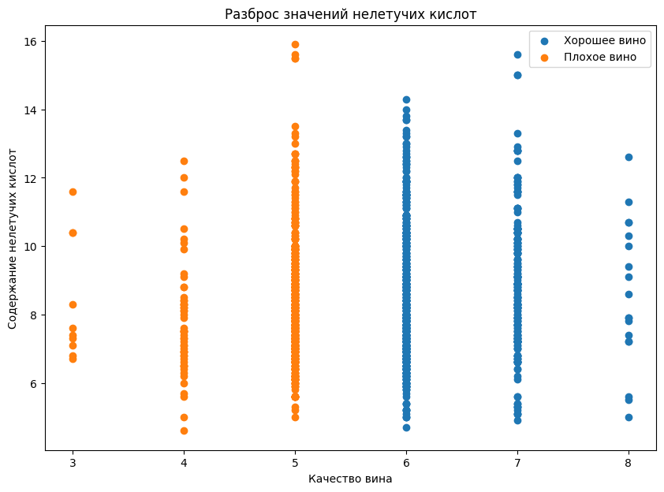

```python
plt.figure(figsize = (10,7))
data_good = df[df['good'] == 1]
data_bad = df[df['good'] == 0]

plt.scatter(data_good['quality'], data_good['fixed acidity'], label = 'Хорошее вино')
plt.scatter(data_bad['quality'], data_bad['fixed acidity'], label = 'Плохое вино')
# plt.scatter(df['fixed acidity'].loc[df['good'] == 0], df['quality'].loc[df['good'] == 0], label = 'Плохое вино')

plt.title('Разброс значений нелетучих кислот')
plt.xlabel('Качество вина')
plt.ylabel('Содержание нелетучих кислот')
plt.legend(['Хорошее вино','Плохое вино'])

plt.show()
```

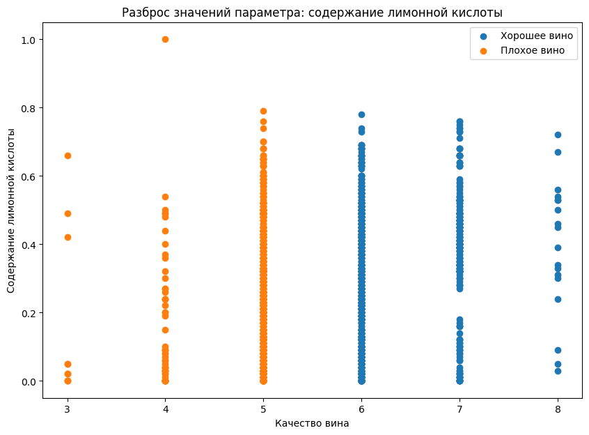

```python
plt.figure(figsize = (10,7))

plt.scatter(data_good['quality'], data_good['citric acid'], label = 'Хорошее вино')
plt.scatter(data_bad['quality'], data_bad['citric acid'], label = 'Плохое вино')
# plt.scatter(df['fixed acidity'].loc[df['good'] == 0], df['quality'].loc[df['good'] == 0], label = 'Плохое вино')

plt.title('Разброс значений параметра: содержание лимонной кислоты')
plt.xlabel('Качество вина')
plt.ylabel('Содержание лимонной кислоты')
plt.legend(['Хорошее вино','Плохое вино'])

plt.show()
```

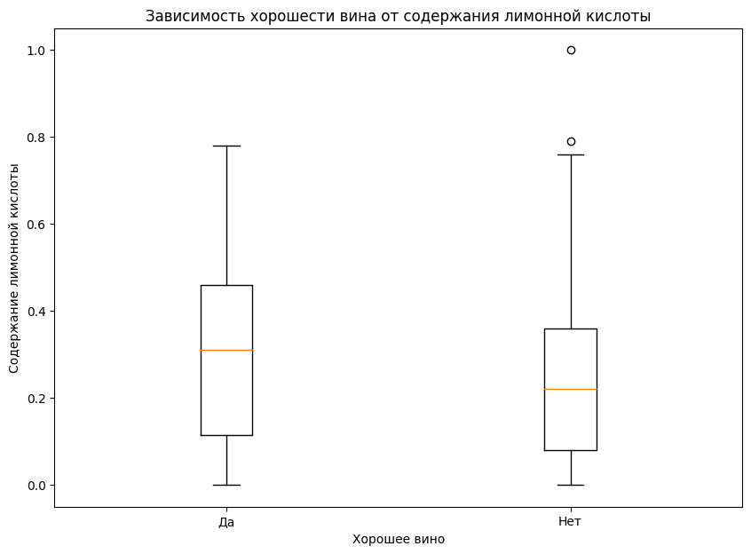

```python
plt.figure(figsize = (10,7))

plt.boxplot([data_good['citric acid'], data_bad['citric acid']], showfliers = True)

plt.title('Зависимость хорошести вина от содержания лимонной кислоты')
plt.xlabel('Хорошее вино')
plt.ylabel('Содержание лимонной кислоты')
plt.xticks([1, 2],['Да', 'Нет'])

plt.show()
```

### Выводы

Следующие химические характеристики вина влияют на то, окажется оно хорошим или плохим:

- содержание алкоголя (крече - лучше);
- содержание летучих кислот (ниже - лучше).